# Circadian Genes *cycle* and *Clock* control Sleep Patterns in *Drosophila melanogaster*

by Jordan Schneider

October 1, 2021

# Background

### This dataset was obtained from [Data Dryad](https://journals.plos.org/plosgenetics/article?id=10.1371/journal.pgen.1006507). It can be found in the supplementary data from the 2017 study entitled “Drosophila Clock Is Required in Brain Pacemaker Neurons to Prevent Premature Locomotor Aging Independently of Its Circadian Function.” In this study, Vaccaro et al. discuss how the loss of circadian genes promotes locomotor aging and shortened lifespan by altering dopaminergic neuron activity. I chose this dataset because as an undergraduate, I studied the molecular mechanisms governing the wake-versus-sleep decision in *C. elegans*. Like Drosophila, *C. elegans* also display cyclical periods of arrest that are analogous to circadian rhythms.

# Setting up the Dataframe

### Prior to importing the dataset, I modified dataframe to have the following specifications:

```
## Rows: 256
## Columns: 37
## $ genotype          <chr> "Cs", "Cs", "Cs", "Cs", "Cs", "Cs", "Cs", "Cs", "Cs"…
## $ light             <chr> "LD", "LD", "LD", "LD", "LD", "LD", "LD", "LD", "LD"…
## $ h1                <dbl> 50, 49, 52, 23, 18, 28, 34, 28, 25, 0, 22, 16, 7, 0,…
## $ h2                <dbl> 54, 44, 42, 35, 48, 41, 41, 26, 26, 29, 39, 34, 47, …
## $ h3                <dbl> 60, 55, 50, 45, 46, 39, 34, 50, 38, 42, 37, 30, 40, …
## $ h4                <dbl> 51, 60, 46, 54, 52, 46, 45, 56, 11, 37, 38, 41, 26, …
## $ h5                <dbl> 55, 60, 47, 41, 37, 34, 53, 32, 31, 36, 34, 27, 31, …
## $ h6                <dbl> 59, 60, 40, 52, 28, 18, 32, 40, 42, 35, 41, 40, 45, …
## $ h7                <dbl> 52, 57, 59, 49, 41, 48, 48, 40, 29, 25, 16, 17, 35, …
## $ h8                <dbl> 35, 51, 34, 25, 8, 6, 14, 24, 21, 28, 24, 16, 41, 23…
## $ h9                <dbl> 18, 36, 28, 26, 32, 19, 20, 23, 15, 29, 0, 0, 22, 12…
## $ h10               <dbl> 8, 20, 18, 0, 0, 0, 0, 10, 0, 2, 13, 7, 0, 0, 6, 9, …
## $ h11               <dbl> 0, 6, 0, 0, 0, 0, 0, 0, 0, 0, 0, 0, 0, 0, 0, 0, 0, 0…
```

[output cut: 24 more lines]

### In order to get rid of any rows with missing data, I ran the following code:

```r
CleanFlyData <- na.omit(FlyClock)
dim(CleanFlyData)
```

```
## [1] 252  37
```

# Analysis

### This supplementary dataset compares flies possessing mutations in two key circadian rhythmn genes, *Clock* (*Clk*) and *cycle* (*cyc*), to control flies (Cs). *Clk* and *cyc* encode transcription factors that form a heterodimer to control the expression of genes like *period* and *timeless*. The authors wanted to understand the effects of altering genetic and environmental conditions such as light on the sleep behavior of flies. In order to do so, Vaccaro et al. subjected circadian mutant flies to either 24 hours of light (LL) or standard, 12 hour light-dark periods (LD).

### First, I wanted to identify the fly that slept for the longest amount of time. In order to do so, I arranged the dataset in descending order.

```
## # A tibble: 252 × 37
##    genotype light    h1    h2    h3    h4    h5    h6    h7    h8    h9   h10
##    <chr>    <chr> <dbl> <dbl> <dbl> <dbl> <dbl> <dbl> <dbl> <dbl> <dbl> <dbl>
##  1 cyc      LL       59    35    18    26    60    60    60    38    60    60
##  2 cyc      LL       55    54    37    38    59    58    52    56    54    57
##  3 cyc      LL       50    33    53    47    60    41    45    45    47    35
##  4 Clk AR   LL       40    53    52    54    60    44    49    44    48    49
##  5 cyc      LL       46    52    54    54    59    49    45    57    49    53
##  6 Cs       LD       49    44    55    60    60    60    57    51    36    20
##  7 cyc      LL       60    57    55    43    49    52    53    55    41    44
##  8 Cs       LL       34    55    60    39    59    54    57    52    55    58
##  9 Clk AR   LL       47    35    27    33     0    42    60    51    56    48
## 10 cyc      LL       55    41    49    56    42    45    55    40    45     9
## # … with 242 more rows, and 25 more variables: h11 <dbl>, h12 <dbl>, h13 <dbl>,
## #   h14 <dbl>, h15 <dbl>, h16 <dbl>, h17 <dbl>, h18 <dbl>, h19 <dbl>,
## #   h20 <dbl>, h21 <dbl>, h22 <dbl>, h23 <dbl>, h24 <dbl>, latency <dbl>,
## #   total <dbl>, day_bout <dbl>, max_day_bout <dbl>, night_bout <dbl>,
## #   max_night_bout <dbl>, day_bout_number <dbl>, night_bout_number <dbl>,
## #   max_rest_time <dbl>, day_sleep <dbl>, night_sleep <dbl>
```

### Surprisingly, a *cyc* mutant exposed to constant light (LL) slept the longest, sleeping a total of 1261 minutes (or about 21 hours) in 24 hours. This result suggests that disrupting both circadian gene function and light exposure could result in striking changes in sleep patterns.

### This result made me curious if genotype had a significant impact on the total time flies spent sleeping. In order to do so, I started by creating two seperate datasets: one for LL flies and the other for LD flies.

```r
LL_Dataset <- CleanFlyData %>%
  filter(light == "LL")

LD_Dataset <- CleanFlyData %>%
  filter(light == "LD")
```

### In order to determine how mutations in circadian genes affect the total sleep of flies exposed to normal LD conditions, I compared genotype to the total sleep of LD flies.

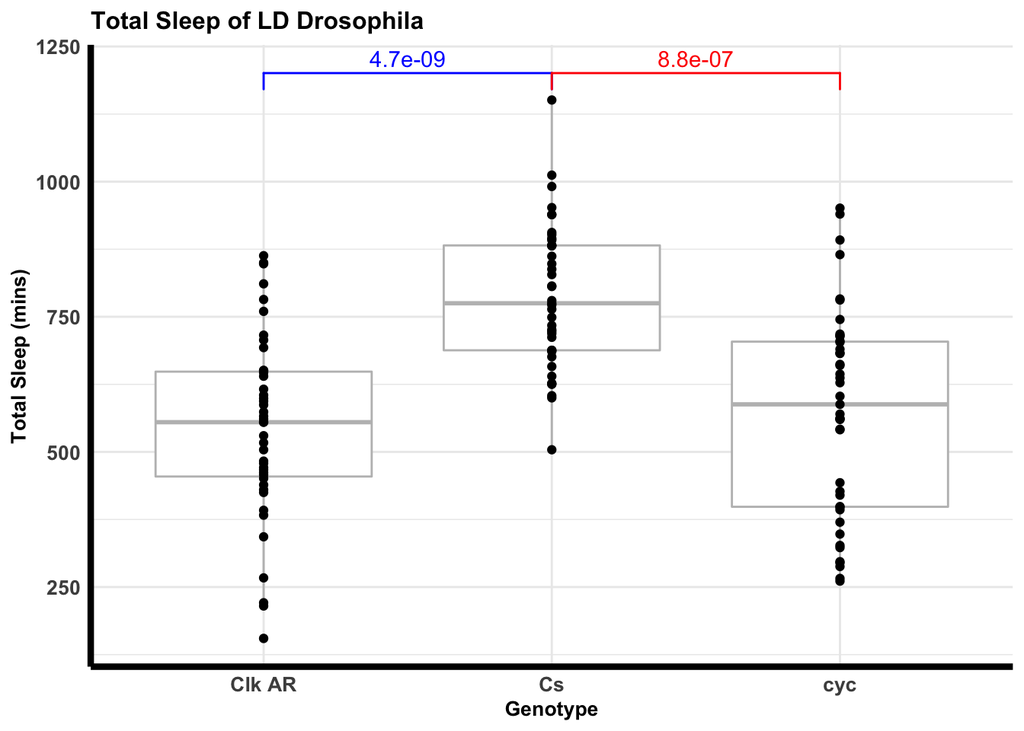

### By this comparison, it appears that mutations in *Clk* and *cyc* result in decreased total sleep, suggesting that mutations in the circadian genes cause flies to sleep less overall under normal LD conditions.

### In order to understand how environmental changes in light exposure may alter these results, I compared genotype to the total sleep of flies exposed contant light conditions (LL).

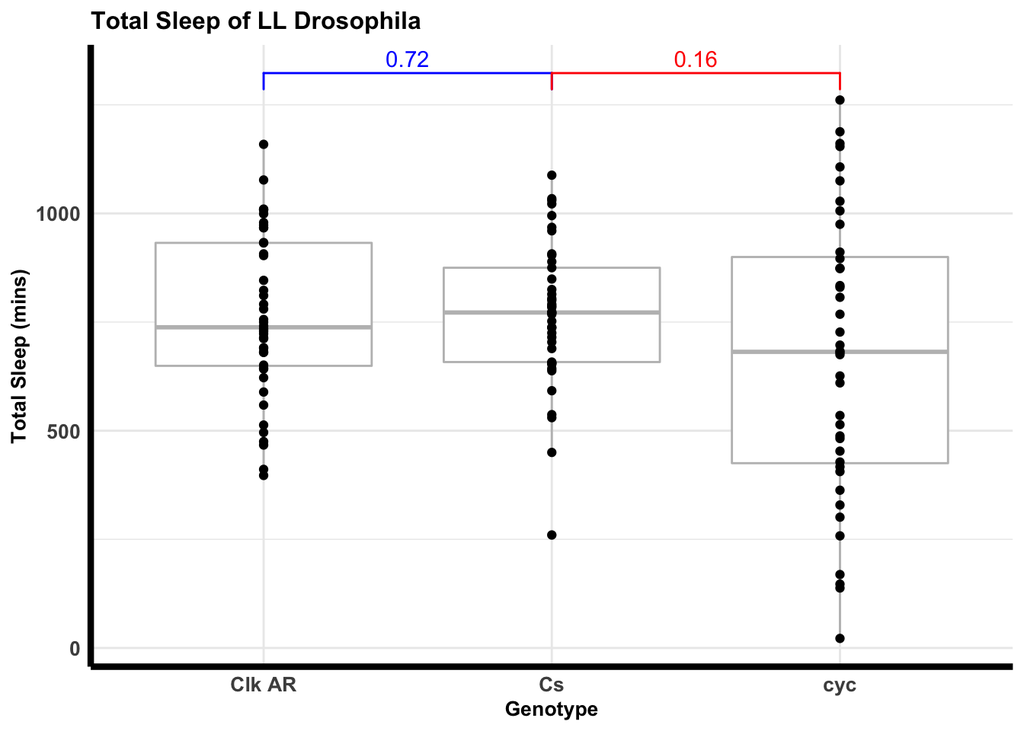

### Unlike the previous result, it appears that exposure to constant light (LL) affects all of the genotypes similarly, since circadian mutant flies do not differ significantly from wild-type.

### Next, I wanted to determine if the duration of light exposure could significantly alter time spent sleeping at night, specifically, across all genotypes.

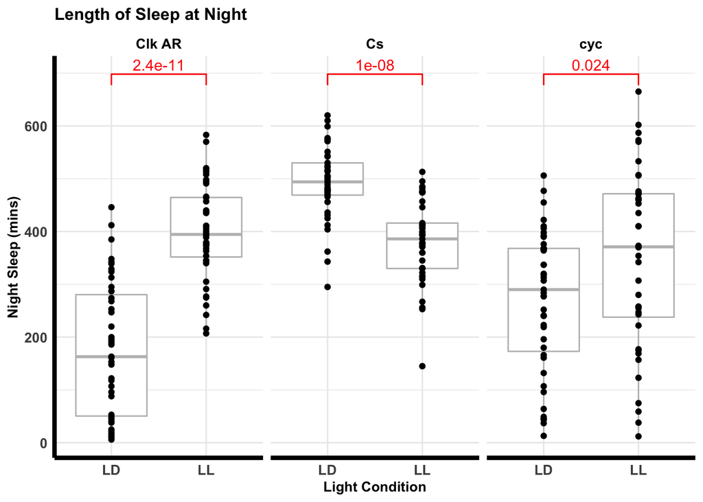

### As one would expect, it appears that exposing wild-type flies to constant light decreases time spent sleeping at night. Interestingly, the circadian mutant flies appear to spend more time asleep at night when they are exposed to constant light conditions than when they are exposed to normal light-dark conditions. These result reinforce the idea that sleep is dependent on both gene function and environmental conditions like light duration.

### Next, I wanted to see if there was a correlation between the number of sleep bouts at night and the average duration of sleep bouts at night across the two conditions

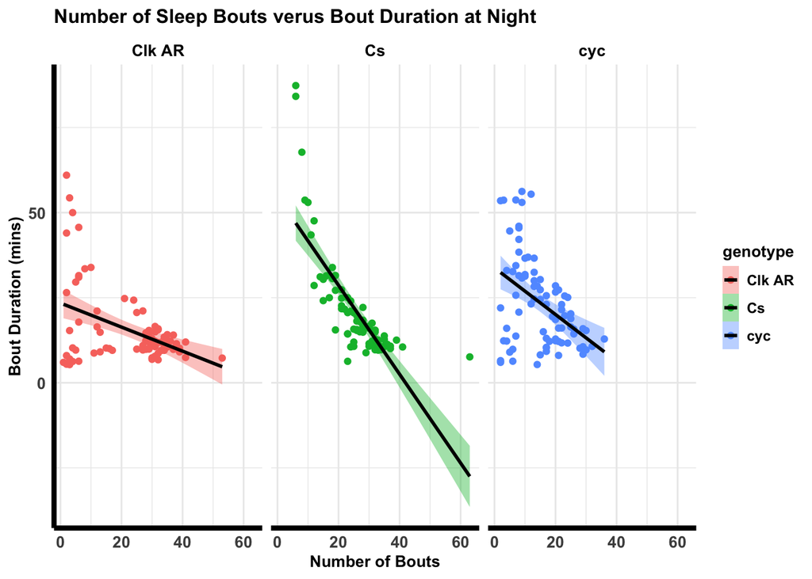

### Based on the slope of the lines above, it becomes clear that *Clk* and *cyc* mutants experience a weaker correlation in sleep bout number and sleep bout duration compare to wild-type. These results confirm that Clk and cyc are important for the normal regulation of sleep bout duration and frequency. Mutating either of these genes results in aberrent sleep patterns, indicative of altered circadial rhythms.

# Conclusion

### Based on the data above, it appears that Clk and cyc are critical for the regulation of normal sleep behavior in flies. Additionally, this behavior is co-dependent on environmental conditions like light exposure. Disrupting Clk and cyc results in unregulated sleep bout patterns at night, regardless of light duration.

# Follow up studies

### In the future, it would be interesting to determine how mutations in light-sensing pathway genes like pigment dispersing factor (PDF) regulate circadian rhythms in the flies. Additionally, it would be interesting to compare how sleep duration at night correlates to the abundance of ROS, since one of the proposed function of sleep is to reduce oxidative damage.

# Acknowledgements

### Thank you [samhsa.gov](https://www.datafiles.samhsa.gov/get-help/format-specific-issues/how-do-i-read-data-r) for teaching me the read_excel() command. Also, thank you to my undergraduate advisor, Dr. Bruce Wightman of Muhlenberg College, for inspiring this project idea. His investigation into the molecular mechanisms governing the wake-versus-sleep decision in *C. elegans* served as the fundation for my data search.